# Using the STAC catalogue to load current and future climate data

## Loading future climate data

We load the climate data projection from the collection “chelsa-clim-proj”, still using the observations points as an extent. The structure of the function is very similar to load_cube, except that the user has to select the climatic scenario (for now, “ssp126”, “ssp370”, or “ssp585”) and the time span (“2041-2070” or “2071-2100”).

```r
cube.future <- load_cube_projection(stac_path =
                                    "http://io.biodiversite-quebec.ca/stac/",
                                  limit = 5000,
                                  collections = c('chelsa-clim-proj'),
                                  use.obs = T,
                                  obs = obs.coords.proj,
                                  buffer.box = 0,
                                  rcp = 'ssp126', #ssp126, ssp370, ssp585
                                  bbox = NULL, layers = layers,
                                  srs.cube = srs.cube,
                                  time.span = "2041-2070", #2041-2070 or 2071-2100
                                  spatial.res = 1000,
                                  temporal.res  = "P1Y", aggregation = "mean",
                                  resampling = "near")
```

Variable extraction also uses the extract_geom function but the output is different. The output table contains one column per variable and per climatic model.

```r
value.points.future <- extract_geom(cube.future, sf::st_as_sf(obs.coords.proj, coords = c("lon", "lat"),
                                                         crs = srs.cube))
value.points.future <- dplyr::bind_cols(data.frame(obs.coords.proj),
                              value.points.future) %>% dplyr::rename(id = FID)

head(value.points.future)
```

```
##           lon         lat  id time bio13_2041-2070_gfdl-esm4_ssp126
## 1  -771158.66 -469612.995 377 2041                             2068
## 2   -90915.85   14126.458 104 2041                             2264
## 3   -90915.02   14128.216 791 2041                             1605
## 4   -92224.16    2490.329 618 2041                             1488
## 5  -797049.41 -311368.233 583 2041                             1481
## 6 -1243965.69  271292.899 373 2041                             1646
##   bio13_2041-2070_ipsl-cm6a-lr_ssp126 bio13_2041-2070_mpi-esm1-2-hr_ssp126
## 1                                2247                                 1758
## 2                                2400                                 1917
## 3                                1434                                 1303
## 4                                1373                                 1277
## 5                                1360                                 1270
## 6                                1422                                 1465
##   bio13_2041-2070_mri-esm2-0_ssp126 bio13_2041-2070_ukesm1-0-ll_ssp126
```

[output cut: 27 more lines]

We extract the name of the variable, the year, the model and the scenario from the column names, then we aggregate the value by point and bioclimatic variable using the mean (we could use another function such as mdeian, min, etc.)

```r
value.points.future <- value.points.future %>% tidyr::pivot_longer(
    cols = dplyr::starts_with("bio"),
    names_to = c("variable", "year", "model", "scenario"),
    names_pattern = "(.*)_(.*)_(.*)_(.*)",
    values_to = "value"
  )  %>%
  dplyr::group_by(id, lon, lat, variable) %>% dplyr::summarise(mean = mean(value))
head(value.points.future)
```

```
## # A tibble: 6 x 5
## # Groups:   id, lon, lat [3]
##      id      lon      lat variable  mean
##   <int>    <dbl>    <dbl> <chr>    <dbl>
## 1     1  383415.   97922. bio13    1155.
## 2     1  383415.   97922. bio6     2721
## 3     2 -613271. -319724. bio13    1434.
## 4     2 -613271. -319724. bio6     2656.
## 5     3 -766738. -501136. bio13    1434.
## 6     3 -766738. -501136. bio6     2656.
```

We eventually convert the data into a tidy dataframe.

```r
value.points.future <- value.points.future %>%
     tidyr::pivot_wider(names_from = variable, values_from = mean)
head(value.points.future)
```

```
## # A tibble: 6 x 5
## # Groups:   id, lon, lat [6]
##      id      lon      lat bio13  bio6
##   <int>    <dbl>    <dbl> <dbl> <dbl>
## 1     1  383415.   97922. 1155. 2721
## 2     2 -613271. -319724. 1434. 2656.
## 3     3 -766738. -501136. 1434. 2656.
## 4     4 -609750. -253636. 1415. 2664.
## 5     5 -419023.  -88575. 1260. 2685.
## 6     6 -877459. -169889.  975. 2636.
```

## Loading land cover data

```r
cube <-
  load_cube(stac_path = "http://io.biodiversite-quebec.ca/stac/",
           limit = 5000,
           collections = c("esacci-lc"),
           use.obs = T,
           obs = obs.coords.proj,
           buffer.box = 0,
           srs.cube = srs.cube,
           t0 = "2000-01-01",
           t1 = "2000-12-31",
           spatial.res = 1000, # in meters
           temporal.res =  "P1Y",
           aggregation = "mean",
           resampling = "near")
```

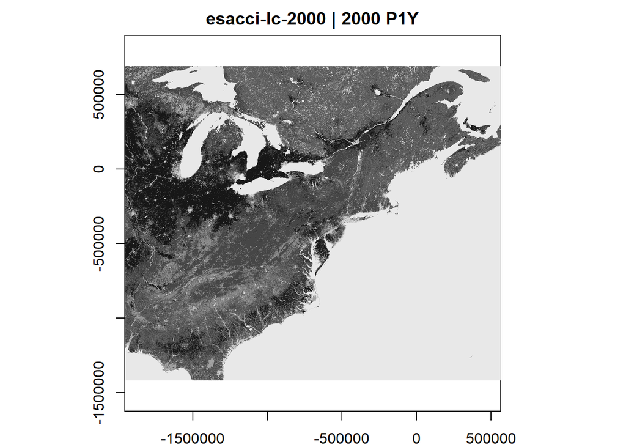

```r
plot(cube %>% select_bands("esacci-lc-2000"))
```

## Loading global human modification index

```r
cube <-
  load_cube(stac_path = "http://io.biodiversite-quebec.ca/stac/",
           limit = 5000,
           collections = c("ghmts"),
           use.obs = T,
           obs = obs.coords.proj,
           buffer.box = 0,
           srs.cube = srs.cube,
           t0 = "2016-01-01",
           t1 = "2016-01-01",
           spatial.res = 1000, # in meters
           temporal.res = "P1Y",
           aggregation = "mean",
           resampling = "near")
```

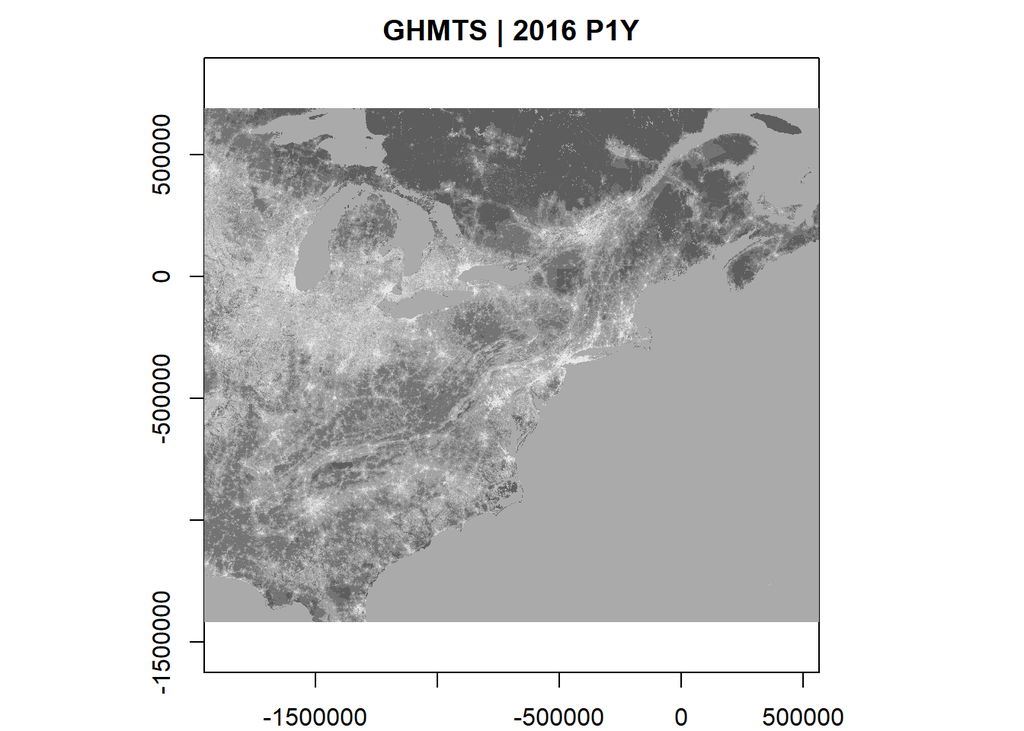

```r
plot(cube)
```

### To continue: usefull ressources

- gdalcube doc: https://cran.r-project.org/web/packages/gdalcubes/gdalcubes.pdf
- Examples based on gdalcubes library: https://github.com/appelmar/gdalcubes_R